# **Traffic Congestion and Parking Zone Impact in Melbourne**

**Authored by:** Sabih Ul Hassan

**Duration:** 90 mins  
**Level:** Intermediate  
**Pre-requisite Skills:** Python, Data Analysis, Geospatial Analysis, Correlation Analysis, Traffic Flow Modeling

### Scenario

I am tasked with analyzing the relationship between parking turnover and traffic congestion within the City of Melbourne. This project aims to explore how specific parking zones affect traffic flow, with the goal of identifying high-demand areas where parking usage contributes to congestion. The insights gained will help optimize parking policies, alleviate congestion in key areas, enhance urban mobility, and reduce travel times for residents.

### What this use case will teach you

At the end of this use case, you will:

- Learn to clean and preprocess parking and traffic datasets effectively.
- Explore geospatial and temporal patterns to identify high-demand and congestion-prone zones.
- Quantify the relationship between parking turnover and traffic flow through correlation analysis.
- Use predictive modeling to identify key factors influencing traffic congestion.
- Develop targeted recommendations for parking policy optimization and congestion relief.

### Background and Introduction

Parking turnover and traffic congestion are closely linked in urban areas, where high-demand parking zones often contribute to traffic slowdowns. In Melbourne, analyzing this relationship is essential for devising data-driven solutions that enhance traffic flow and reduce congestion. This use case examines parking zones, on-street parking bays, and historical traffic data to gain insights into how parking influences traffic flow. By identifying congestion-prone zones and analyzing parking dynamics, this project will offer targeted policy recommendations to optimize parking practices and improve urban mobility.

### Datasets Used

1. **Parking Zones Linked to Street Segments:** Contains information on parking zones, restrictions, and associated street segments in Melbourne.
2. **On-Street Parking Bays:** Details the location, usage, and turnover rates of on-street parking bays.
3. **Traffic Count Vehicle Classification (2014-2017):** Provides traffic volume data by vehicle type, segmented by location and time, capturing trends over several years.

These datasets are sourced from the City of Melbourne's open data portal.

# **Importing Libaries**

```python
!pip install contextily
!pip install ace_tools
```

```python
import requests
import pandas as pd
import os
from io import StringIO
import folium
from folium.plugins import HeatMap
from shapely.geometry import Point
import geopandas as gpd
import matplotlib.pyplot as plt
import contextily as ctx  # For basemaps
from folium.plugins import MarkerCluster
from IPython.display import display

from sklearn.model_selection import train_test_split, cross_val_score
from sklearn.ensemble import RandomForestRegressor
from sklearn.metrics import mean_squared_error, r2_score
import seaborn as sns
```

# **Importing Datasets**

Use this if importing with API, comment this out if importing downloaded datasets

```python
def API_Unlimited(datasetname): # pass in dataset name and api key
    dataset_id = datasetname

    base_url = 'https://data.melbourne.vic.gov.au/api/explore/v2.1/catalog/datasets/'
    #apikey = api_key
    dataset_id = dataset_id
    format = 'csv'

    url = f'{base_url}{dataset_id}/exports/{format}'
    params = {
        'select': '*',
        'limit': -1,  # all records
        'lang': 'en',
        'timezone': 'UTC'
    }

    # GET request
    response = requests.get(url, params=params)

    if response.status_code == 200:
        # StringIO to read the CSV data
        url_content = response.content.decode('utf-8')
        datasetname = pd.read_csv(StringIO(url_content), delimiter=';')
        print(datasetname.sample(10, random_state=999)) # Test
        return datasetname
    else:
        return (print(f'Request failed with status code {response.status_code}'))
```

```python
download_link_1 = 'traffic-count-vehicle-classification-2014-2017'
download_link_2 = 'parking-zones-linked-to-street-segments'
download_link_3 = 'on-street-parking-bays'


# Use functions to download and load data
traffic_count_df = API_Unlimited(download_link_1)
parking_zones_df = API_Unlimited(download_link_2)
parking_bays_df = API_Unlimited(download_link_3)
```

```
             date            road_name  \
2711   2015-10-23        Bourke Street
54109  2015-03-09  Princess Park Drive
47736  2015-08-26      Gatehouse Drive
28042  2016-10-13     Gatehouse Street
59703  2014-09-11      Tennyson Street
31485  2017-05-03           Epsom Road
11816  2015-05-30        Lytton Street
15809  2014-04-02     Elizabeth Street
36506  2014-10-11      Wolseley Parade
54876  2015-03-09         Story Street

                                               location         suburb  \
2711           Between Geographe Street and Import Lane      Docklands
54109                        South of MacPherson Street  Carlton North
```

[output cut: 116 more lines]

```python
# Display the first few rows and summary statistics for each dataset
print("Traffic count vehicle calssification Dataset:")
print(traffic_count_df.head())
print(traffic_count_df.info())

print("\nParking zone Dataset:")
print(parking_zones_df.head())
print(parking_zones_df.info())

print("\nOn street Parking bays Dataset:")
print(parking_bays_df.head())
print(parking_bays_df.info())
```

```
Traffic count vehicle calssification Dataset:
         date     road_name                location      suburb  speed_limit  \
0  2016-04-29  Rankins Road  North of Macaulay Road  Kensington           50
1  2016-04-29  Rankins Road  North of Macaulay Road  Kensington           50
2  2016-04-29  Rankins Road  North of Macaulay Road  Kensington           50
3  2016-04-29  Rankins Road  North of Macaulay Road  Kensington           50
4  2016-04-29  Rankins Road  North of Macaulay Road  Kensington           50

  direction   time  vehicle_class_1  vehicle_class_2  vehicle_class_3  ...  \
0         S   3:00              1.0              0.0              0.0  ...
1         S   5:00              6.0              0.0              0.0  ...
2         S   8:00             70.0              0.0              0.0  ...
3         S  10:00             34.0              0.0              2.0  ...
4         S  12:00             33.0              0.0              4.0  ...

   vehicle_class_12  vehicle_class_13  motorcycle  bike  average_speed  \
0               0.0               0.0         0.0   0.0           14.0
1               0.0               0.0         0.0   2.0           24.0
2               0.0               1.0         2.0  13.0           26.0
3               0.0               0.0         0.0   4.0           24.0
4               0.0               0.0         1.0   4.0           22.0

   85th_percentile_speed  maximum_speed  road_segment  road_segment_1  \
0                   13.0             14         23071             NaN
1                   28.0             30         23071             NaN
2                   29.0             38         23071             NaN
3                   27.0             34         23071             NaN
4                   28.0             32         23071             NaN

   road_segment_2
0             NaN
1             NaN
2             NaN
3             NaN
4             NaN

[5 rows x 28 columns]
<class 'pandas.core.frame.DataFrame'>
RangeIndex: 60168 entries, 0 to 60167
Data columns (total 28 columns):
```

[output cut: 83 more lines]

```
<class 'pandas.core.frame.DataFrame'>
RangeIndex: 23864 entries, 0 to 23863
Data columns (total 7 columns):
 #   Column                  Non-Null Count  Dtype
---  ------                  --------------  -----
 0   roadsegmentid           23864 non-null  int64
 1   kerbsideid              5339 non-null   object
 2   roadsegmentdescription  23864 non-null  object
 3   latitude                23864 non-null  float64
 4   longitude               23864 non-null  float64
 5   lastupdated             23864 non-null  object
 6   location                23864 non-null  object
dtypes: float64(2), int64(1), object(4)
memory usage: 1.3+ MB
None
```

```python
print(parking_bays_df.columns)
print(parking_zones_df.columns)
```

```
Index(['roadsegmentid', 'kerbsideid', 'roadsegmentdescription', 'latitude',
       'longitude', 'lastupdated', 'location'],
      dtype='object')
Index(['parkingzone', 'onstreet', 'streetfrom', 'streetto', 'segment_id'], dtype='object')
```

```python
# Step 1: Standardize column names
parking_bays_df.rename(columns={'roadsegmentid': 'Segment_ID'}, inplace=True)
parking_zones_df.rename(
    columns={
        'parkingzone': 'ParkingZone',
        'onstreet': 'OnStreet',
        'streetfrom': 'StreetFrom',
        'streetto': 'StreetTo',
        'segment_id': 'Segment_ID'
    },
    inplace=True)
traffic_count_df.rename(columns={'road_segment': 'Segment_ID'}, inplace=True)

# Step 2: Inspect missing values
print("Missing values in Parking Bays dataset:")
print(parking_bays_df.isnull().sum())

print("\nMissing values in Parking Zones dataset:")
print(parking_zones_df.isnull().sum())

print("\nMissing values in Traffic Count dataset:")
print(traffic_count_df.isnull().sum())

# Step 3: Drop rows with critical missing data
parking_bays_df_cleaned = parking_bays_df.dropna(subset=['Segment_ID'])
parking_zones_df_cleaned = parking_zones_df.dropna(subset=['StreetTo'])
traffic_count_df_cleaned = traffic_count_df.dropna(subset=['time', 'average_speed'])

# Ensure time parsing is consistent
traffic_count_df_cleaned['time'] = pd.to_datetime(traffic_count_df_cleaned['time'].str.strip(), format='%H:%M', errors='coerce')

# Step 4: Merge datasets in logical order
# Merge Parking Bays and Parking Zones
merged_parking_data = pd.merge(parking_bays_df_cleaned, parking_zones_df_cleaned, on='Segment_ID', how='inner')

# Merge the result with Traffic Count data
final_merged_data = pd.merge(merged_parking_data, traffic_count_df_cleaned, on='Segment_ID', how='inner')

# Step 5: Address missing values in specific columns
final_merged_data['maximum_speed'] = pd.to_numeric(final_merged_data['maximum_speed'], errors='coerce')

# Optimize memory usage
for col in final_merged_data.select_dtypes(include=['float64']).columns:
    final_merged_data[col] = pd.to_numeric(final_merged_data[col], downcast='float')
for col in final_merged_data.select_dtypes(include=['int64']).columns:
    final_merged_data[col] = pd.to_numeric(final_merged_data[col], downcast='integer')
print("Memory optimization complete.")

# Step 6: Validate and save the final dataset
print("\nUpdated Final Merged Dataset Info:")
print(final_merged_data.info())

final_merged_data.to_csv("cleaned_final_data.csv", index=False)
print("Cleaned merged data saved as 'cleaned_final_data.csv'")

# Generate and save missing data summary
missing_summary = final_merged_data.isnull().sum()
print("\nMissing Data Summary:")
print(missing_summary)
missing_summary.to_csv("missing_data_summary.csv", index=True)
```

```
Missing values in Parking Bays dataset:
Segment_ID                    0
kerbsideid                18525
roadsegmentdescription        0
latitude                      0
longitude                     0
lastupdated                   0
location                      0
dtype: int64

Missing values in Parking Zones dataset:
ParkingZone    0
OnStreet       0
StreetFrom     0
StreetTo       4
Segment_ID     0
dtype: int64

Missing values in Traffic Count dataset:
date                         0
road_name                    0
location                     0
suburb                       0
speed_limit                  0
direction                    0
time                         0
vehicle_class_1            112
vehicle_class_2            112
vehicle_class_3            112
vehicle_class_4            112
vehicle_class_5            112
vehicle_class_6            112
vehicle_class_7            112
vehicle_class_8            112
vehicle_class_9            112
vehicle_class_10           112
vehicle_class_11           112
vehicle_class_12           112
vehicle_class_13           112
motorcycle               15256
bike                     15256
average_speed             5008
85th_percentile_speed     5009
maximum_speed            15024
Segment_ID                   0
road_segment_1           55128
road_segment_2           56136
dtype: int64
```

```
Memory optimization complete.

Updated Final Merged Dataset Info:
<class 'pandas.core.frame.DataFrame'>
RangeIndex: 659032 entries, 0 to 659031
Data columns (total 38 columns):
 #   Column                  Non-Null Count   Dtype
---  ------                  --------------   -----
 0   Segment_ID              659032 non-null  int16
 1   kerbsideid              136506 non-null  object
 2   roadsegmentdescription  659032 non-null  object
 3   latitude                659032 non-null  float32
 4   longitude               659032 non-null  float32
 5   lastupdated             659032 non-null  object
 6   location_x              659032 non-null  object
 7   ParkingZone             659032 non-null  int16
 8   OnStreet                659032 non-null  object
 9   StreetFrom              659032 non-null  object
 10  StreetTo                659032 non-null  object
 11  date                    659032 non-null  object
 12  road_name               659032 non-null  object
 13  location_y              659032 non-null  object
 14  suburb                  659032 non-null  object
 15  speed_limit             659032 non-null  int8
 16  direction               659032 non-null  object
 17  time                    659032 non-null  datetime64[ns]
 18  vehicle_class_1         659032 non-null  float32
 19  vehicle_class_2         659032 non-null  float32
 20  vehicle_class_3         659032 non-null  float32
 21  vehicle_class_4         659032 non-null  float32
 22  vehicle_class_5         659032 non-null  float32
 23  vehicle_class_6         659032 non-null  float32
 24  vehicle_class_7         659032 non-null  float32
 25  vehicle_class_8         659032 non-null  float32
 26  vehicle_class_9         659032 non-null  float32
 27  vehicle_class_10        659032 non-null  float32
 28  vehicle_class_11        659032 non-null  float32
 29  vehicle_class_12        659032 non-null  float32
 30  vehicle_class_13        659032 non-null  float32
 31  motorcycle              536979 non-null  float32
```

[output cut: 36 more lines]

```
vehicle_class_7                0
vehicle_class_8                0
vehicle_class_9                0
vehicle_class_10               0
vehicle_class_11               0
vehicle_class_12               0
vehicle_class_13               0
motorcycle                122053
bike                      122053
average_speed                  0
85th_percentile_speed          0
maximum_speed             107380
road_segment_1            569631
road_segment_2            639804
dtype: int64
```

```python
# Fill missing values without using inplace=True
final_merged_data['motorcycle'] = final_merged_data['motorcycle'].fillna(0)
final_merged_data['bike'] = final_merged_data['bike'].fillna(0)
```

# **Exploratory data analysis (EDA)**

```
Summary Statistics for Numerical Columns:
          Segment_ID       latitude      longitude    ParkingZone  \
count  659032.000000  659032.000000  659032.000000  659032.000000
mean    21818.510206     -37.811077     144.961731    7534.755097
min     20036.000000     -37.830910     144.944717    7010.000000
25%     21388.000000     -37.826298     144.953979    7173.000000
50%     22106.000000     -37.814621     144.963028    7529.000000
75%     22392.000000     -37.801743     144.969543    7902.000000
max     23032.000000     -37.778313     144.981995    7965.000000
std       874.320527       0.155534       0.786149     330.824477

         speed_limit                           time  vehicle_class_1  \
count  659032.000000                         659032    659032.000000
mean       48.384403  1900-01-01 11:49:58.151834880        90.118523
min        40.000000            1900-01-01 00:00:00         0.000000
25%        50.000000            1900-01-01 06:00:00        12.000000
50%        50.000000            1900-01-01 12:00:00        41.000000
75%        50.000000            1900-01-01 18:00:00        96.000000
max        50.000000            1900-01-01 23:00:00      1954.000000
std         3.680467                            NaN       156.595917

       vehicle_class_2  vehicle_class_3  vehicle_class_4  ...  \
count    659032.000000    659032.000000    659032.000000  ...
mean          0.463390         3.869814         0.602124  ...
min           0.000000         0.000000         0.000000  ...
25%           0.000000         0.000000         0.000000  ...
50%           0.000000         1.000000         0.000000  ...
75%           0.000000         4.000000         0.000000  ...
max         139.000000       126.000000        32.000000  ...
std           3.304415         8.359927         2.060762  ...

       vehicle_class_11  vehicle_class_12  vehicle_class_13     motorcycle  \
count     659032.000000     659032.000000     659032.000000  659032.000000
mean           0.009148          0.002316          0.048131       1.814671
min            0.000000          0.000000          0.000000       0.000000
25%            0.000000          0.000000          0.000000       0.000000
50%            0.000000          0.000000          0.000000       0.000000
75%            0.000000          0.000000          0.000000       2.000000
max           12.000000          4.000000         16.000000      59.000000
std            0.194656          0.071738          0.374876       4.214932

                bike  average_speed  85th_percentile_speed  maximum_speed  \
count  659032.000000  659032.000000          659032.000000  551652.000000
mean        6.545772      28.157497              33.431076      41.755241
min         0.000000       1.000000               1.000000       1.000000
25%         0.000000      22.000000              26.000000      32.000000
50%         0.000000      28.000000              34.000000      40.000000
75%         4.000000      33.000000              40.000000      50.000000
max       290.000000      94.099998              94.000000     145.000000
std        18.500809       7.306579               8.691720      13.494924

       road_segment_1  road_segment_2
count    89401.000000    19228.000000
mean     22440.308594    21519.615234
min      21387.000000    21383.000000
25%      22394.000000    21383.000000
50%      22394.000000    21383.000000
75%      22912.000000    21383.000000
max      22912.000000    22686.000000
std        562.164734      399.203156

[8 rows x 26 columns]
```

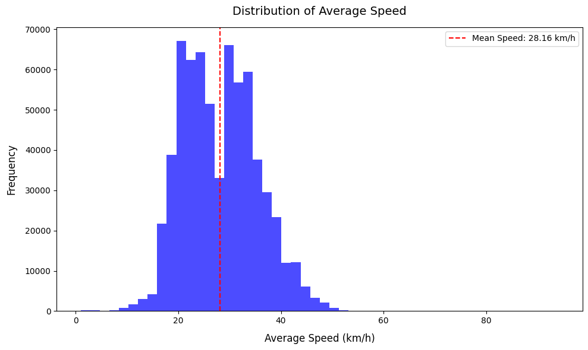

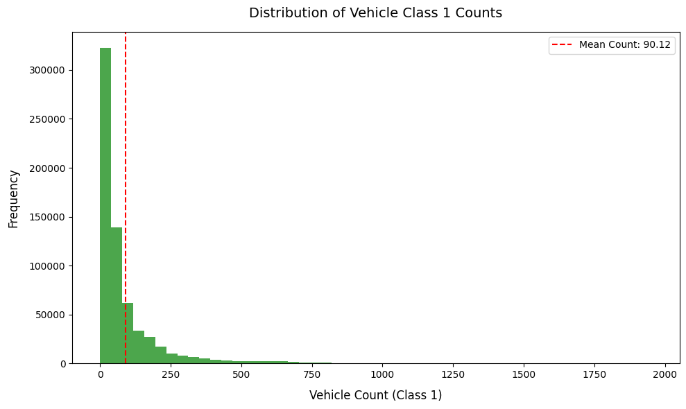

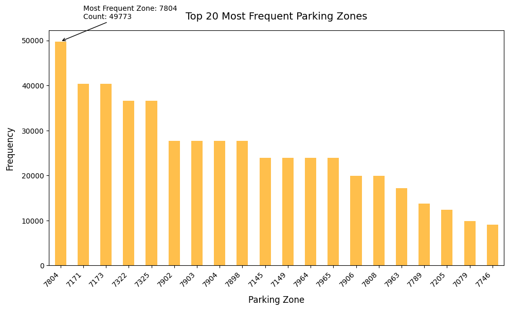

```python
# Summary statistics for key numerical columns
eda_summary = final_merged_data.describe()
print("Summary Statistics for Numerical Columns:")
print(eda_summary)

# Plot distributions for critical traffic metrics

# Average speed distribution
plt.figure(figsize=(10, 6))
final_merged_data['average_speed'].dropna().hist(bins=50, color='blue', alpha=0.7)
mean_speed = final_merged_data['average_speed'].mean()
plt.axvline(mean_speed, color='red', linestyle='--', label=f'Mean Speed: {mean_speed:.2f} km/h')
plt.title('Distribution of Average Speed', fontsize=14, pad=15)
plt.xlabel('Average Speed (km/h)', fontsize=12, labelpad=10)
plt.ylabel('Frequency', fontsize=12, labelpad=10)
plt.legend(fontsize=10)
plt.grid(False)
plt.tight_layout()
plt.show()

# Vehicle count (class 1) distribution
plt.figure(figsize=(10, 6))
final_merged_data['vehicle_class_1'].dropna().hist(bins=50, color='green', alpha=0.7)
mean_vehicle_count = final_merged_data['vehicle_class_1'].mean()
plt.axvline(mean_vehicle_count, color='red', linestyle='--', label=f'Mean Count: {mean_vehicle_count:.2f}')
plt.title('Distribution of Vehicle Class 1 Counts', fontsize=14, pad=15)
plt.xlabel('Vehicle Count (Class 1)', fontsize=12, labelpad=10)
plt.ylabel('Frequency', fontsize=12, labelpad=10)
plt.legend(fontsize=10)
plt.grid(False)
plt.tight_layout()
plt.show()

# Top 20 most frequent parking zones
plt.figure(figsize=(10, 6))
top_parking_zones = final_merged_data['ParkingZone'].value_counts().head(20)
top_parking_zones.plot(kind='bar', color='orange', alpha=0.7)
plt.title('Top 20 Most Frequent Parking Zones', fontsize=14, pad=15)
plt.xlabel('Parking Zone', fontsize=12, labelpad=10)
plt.ylabel('Frequency', fontsize=12, labelpad=10)
plt.xticks(rotation=45, ha='right', fontsize=10)
plt.tight_layout()

# Add annotation for the most frequent parking zone
most_frequent_zone = top_parking_zones.index[0]
most_frequent_count = top_parking_zones.iloc[0]
plt.annotate(
    f"Most Frequent Zone: {most_frequent_zone}\nCount: {most_frequent_count}",
    xy=(0, most_frequent_count),
    xytext=(1, most_frequent_count + 5000),
    arrowprops=dict(facecolor='black', arrowstyle='->'),
    fontsize=10
)
plt.show()
```

# Explanation of Code and Outputs

## 1. **Summary Statistics**

The code calculates and displays the summary statistics for all numerical columns in the dataset. Key statistics such as mean, minimum, maximum, and standard deviation provide a comprehensive overview of the data distribution.

## 2. **Distribution of Average Speed**

- **Visualization**: The histogram illustrates the distribution of average speeds (in km/h) across all data points.
- **Insights**:
  - A red dashed line represents the mean speed, calculated to be approximately 28.16 km/h.
  - The data shows a peak around the 20-30 km/h range, suggesting that most traffic operates at moderate speeds.

## 4. **Top 20 Most Frequent Parking Zones**

- **Visualization**: A bar chart highlights the 20 parking zones with the highest frequencies in the dataset.
- **Improvements**:
  - To avoid overlap, `plt.tight_layout()` ensures the chart is clean and legible.
  - Parking zone labels are rotated 45 degrees to enhance readability.
- **Insights**:
  - The most frequent parking zone is highlighted with an annotation pointing to the corresponding bar.
  - Zone `7804` is the most frequent parking zone, appearing **49,773** times in the data.

## Summary:

This analysis provides insights into traffic patterns, parking zone usage, and vehicle distributions. It combines numerical summaries with meaningful visualizations to interpret the data effectively. The enhancements improve visualization clarity and emphasize critical insights.

# **Geospatial Analysis**

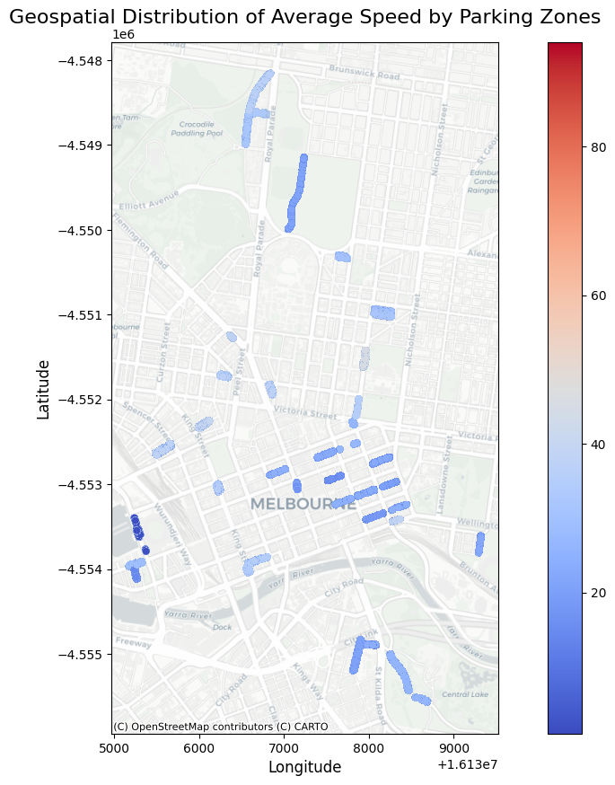

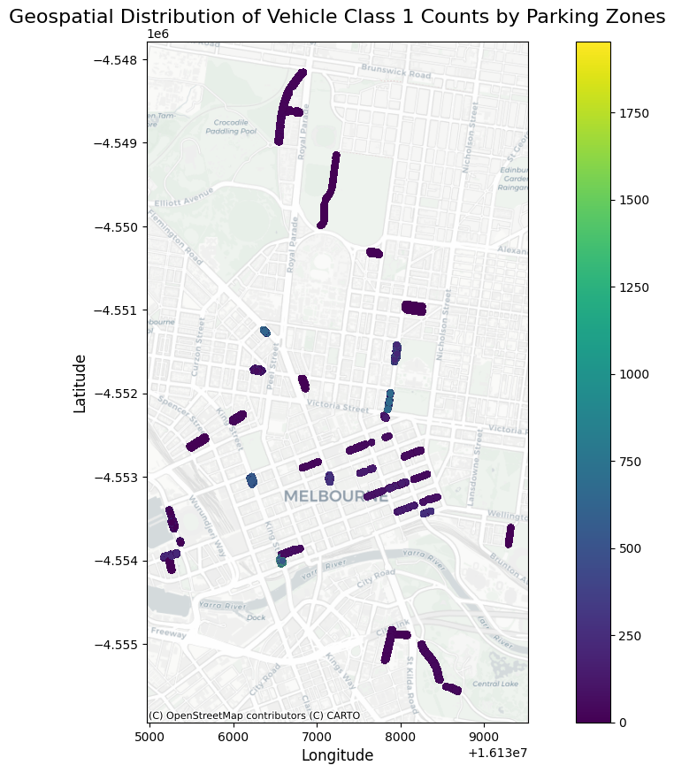

```python
# Create a GeoDataFrame from the merged dataset
geometry = [Point(xy) for xy in zip(final_merged_data['longitude'], final_merged_data['latitude'])]
geo_df = gpd.GeoDataFrame(final_merged_data, geometry=geometry, crs="EPSG:4326")

# Transform to Web Mercator for basemap compatibility
geo_df = geo_df.to_crs(epsg=3857)

# Plot average speed with basemap
fig, ax = plt.subplots(1, 1, figsize=(14, 10))
geo_df.plot(
    ax=ax,
    column='average_speed',
    cmap='coolwarm',
    legend=True,
    markersize=20,
    alpha=0.7
)
ctx.add_basemap(ax, source=ctx.providers.CartoDB.Positron)
ax.set_title('Geospatial Distribution of Average Speed by Parking Zones', fontsize=16, pad=15)
ax.set_xlabel('Longitude', fontsize=12)
ax.set_ylabel('Latitude', fontsize=12)
plt.show()

# Plot vehicle class 1 counts with basemap
fig, ax = plt.subplots(1, 1, figsize=(14, 10))
geo_df.plot(
    ax=ax,
    column='vehicle_class_1',
    cmap='viridis',
    legend=True,
    markersize=20,
    alpha=0.7
)
ctx.add_basemap(ax, source=ctx.providers.CartoDB.Positron)
ax.set_title('Geospatial Distribution of Vehicle Class 1 Counts by Parking Zones', fontsize=16, pad=15)
ax.set_xlabel('Longitude', fontsize=12)
ax.set_ylabel('Latitude', fontsize=12)
plt.show()
```

## Geospatial Analysis of Parking Zones

## Visualization 1: Average Speed by Parking Zones

The first map visualizes the average speed (in km/h) across different parking zones. Using a heatmap with the `coolwarm` color gradient, regions with lower speeds are displayed in cooler tones (blue), while higher speeds are represented by warmer tones (red). This allows us to identify areas of slower traffic flow, indicating potential congestion hotspots.

## Visualization 2: Vehicle Class 1 Counts by Parking Zones

The second map visualizes the counts of `Vehicle Class 1` (likely cars or light vehicles) across parking zones. The `viridis` color scheme is used to show zones with high vehicle counts in brighter yellow tones, while lower counts are represented in darker green or purple. This helps identify zones with high vehicular density.

These visualizations overlay the data on a street map for spatial context, making it easier to analyze patterns related to traffic flow and vehicle density within the city.

# **High-Congestion Parking Zones Analysis**

```python
# Convert numerical columns to float64 to avoid serialization issues
for col in ['average_speed', 'vehicle_class_1', 'latitude', 'longitude']:
    final_merged_data[col] = final_merged_data[col].astype(float)

# Thresholds for congestion
low_speed_threshold = 25  # Speed below 25 km/h
high_vehicle_count_threshold = 100  # Vehicle count above 100

# Filter the data for high-congestion zones
high_congestion_zones = final_merged_data[
    (final_merged_data['average_speed'] < low_speed_threshold) &
    (final_merged_data['vehicle_class_1'] > high_vehicle_count_threshold)
]

# Aggregate data to find most affected parking zones
congestion_summary = high_congestion_zones.groupby('ParkingZone').agg({
    'average_speed': 'mean',
    'vehicle_class_1': 'sum',
    'latitude': 'mean',
    'longitude': 'mean'
}).sort_values(by='vehicle_class_1', ascending=False).reset_index()
```

```python
# Create a base map centered at the mean latitude and longitude
map_center = [congestion_summary['latitude'].mean(), congestion_summary['longitude'].mean()]
m = folium.Map(location=map_center, zoom_start=12, tiles="OpenStreetMap")

# Add MarkerCluster to group markers
marker_cluster = MarkerCluster(name="High Congestion Zones").add_to(m)

# Add CircleMarkers for each congestion zone
for _, row in congestion_summary.iterrows():
    folium.CircleMarker(
        location=[row['latitude'], row['longitude']],
        radius=row['vehicle_class_1'] / 5000,  # Scale radius based on vehicle count
        popup=(f"<b>Parking Zone:</b> {row['ParkingZone']}<br>"
               f"<b>Average Speed:</b> {row['average_speed']:.2f} km/h<br>"
               f"<b>Vehicle Count:</b> {row['vehicle_class_1']}"),
        color='red',
        fill=True,
        fill_color='red',
        fill_opacity=0.7
    ).add_to(marker_cluster)

# Add HeatMap for density visualization
HeatMap(data=congestion_summary[['latitude', 'longitude', 'vehicle_class_1']].values, radius=15).add_to(m)

# Add Layer Control and display map
folium.LayerControl().add_to(m)
display(m)
```

Make this Notebook Trusted to load map: File -> Trust Notebook

[interactive chart not shown]

### **Explanation of Geospatial Analysis and Visualization**

#### **Objective:**

This analysis identifies and visualizes high-congestion parking zones based on two criteria:

- **Low average speed:** Below 25 km/h.
- **High vehicle count (Class 1):** Above 100 vehicles.

The goal is to locate these zones and provide geospatial insights into their distribution.

#### **Code Functionality:**

1. **Data Filtering:**
   - The data is filtered to include only records that meet the high-congestion thresholds:
     - **Average Speed < 25 km/h**
     - **Vehicle Count (Class 1) > 100**
   - Aggregation is performed at the `ParkingZone` level to calculate:
     - Mean **average speed**.
     - Total **vehicle count**.
     - Mean **latitude** and **longitude** for each zone.
2. **Visualization:**
   - A **Folium map** is created, centered around the mean latitude and longitude of the high-congestion zones.
   - Two types of markers are added:
     - **CircleMarkers:** Indicate high-congestion parking zones. The size of each marker represents the total vehicle count for that zone.
     - **HeatMap:** Highlights areas with high vehicle density for a clearer visual understanding of congestion patterns.
3. **Layer Control:**
   - A layer control feature allows toggling between different visualizations (markers and heatmaps).

#### **Key Insights from the Visualization:**

1. **CircleMarkers:**
   - Each marker represents a parking zone with high congestion.
   - The marker size is proportional to the total vehicle count in that zone.
   - Hovering over a marker displays detailed information about:
     - **Parking Zone ID**
     - **Average Speed** (km/h)
     - **Vehicle Count**
2. **HeatMap:**
   - Provides a density-based visualization, highlighting zones with the highest concentration of vehicle traffic.
   - The heatmap helps in understanding the spatial intensity of congestion across the map.

#### **Use Case:**

This visualization is particularly useful for:

- **Urban Traffic Management:**
  - Identifying bottlenecks in parking zones with high vehicle counts and low speeds.
- **Policy Planning:**
  - Informing decisions on optimizing traffic flow or implementing congestion-reducing measures in problem areas.

# **Hourly Trends in High-Congestion Zones**

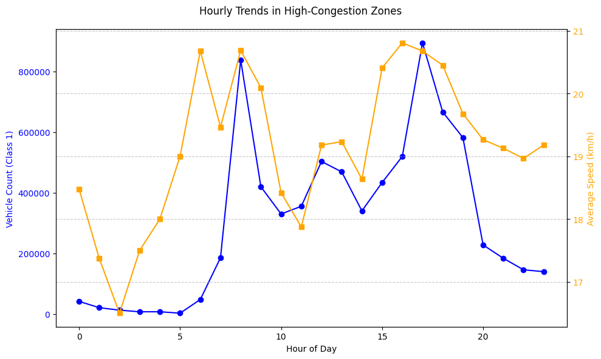

```python
# Ensure 'hour' column is added properly using .loc
high_congestion_zones.loc[:, 'hour'] = high_congestion_zones['time'].dt.hour

# Hourly trends analysis
hourly_analysis = high_congestion_zones.groupby('hour').agg({
    'vehicle_class_1': 'sum',
    'average_speed': 'mean'
}).reset_index()

# Plot hourly trends with dual y-axes
fig, ax1 = plt.subplots(figsize=(10, 6))

# Plot vehicle count on primary y-axis
ax1.plot(hourly_analysis['hour'], hourly_analysis['vehicle_class_1'], marker='o', label='Vehicle Count (Class 1)', color='blue')
ax1.set_xlabel("Hour of Day")
ax1.set_ylabel("Vehicle Count (Class 1)", color='blue')
ax1.tick_params(axis='y', labelcolor='blue')

# Plot average speed on secondary y-axis
ax2 = ax1.twinx()
ax2.plot(hourly_analysis['hour'], hourly_analysis['average_speed'], marker='s', label='Average Speed (km/h)', color='orange')
ax2.set_ylabel("Average Speed (km/h)", color='orange')
ax2.tick_params(axis='y', labelcolor='orange')

# Add grid, legend, and title
fig.suptitle("Hourly Trends in High-Congestion Zones")
fig.tight_layout()
plt.grid(True, linestyle='--', alpha=0.7)
plt.show()
```

### Explanation of the Chart: Hourly Trends in High-Congestion Zones

This chart visualizes the **hourly trends in high-congestion zones**, focusing on two key metrics:

1. **Vehicle Count (Class 1)**, represented on the **left y-axis** (blue line).
2. **Average Speed (km/h)**, represented on the **right y-axis** (orange line).

# **Spatial Analysis During Peak Hours**

```python
# Step 1: Filter the data for peak hours (8-10 AM and 4-6 PM)
peak_hours = high_congestion_zones[
    ((high_congestion_zones['hour'] >= 8) & (high_congestion_zones['hour'] <= 10)) |
    ((high_congestion_zones['hour'] >= 16) & (high_congestion_zones['hour'] <= 18))
]

# Step 2: Aggregate data by parking zones
peak_hour_summary = peak_hours.groupby('ParkingZone').agg({
    'average_speed': 'mean',
    'vehicle_class_1': 'sum',
    'latitude': 'mean',
    'longitude': 'mean'
}).reset_index()

# Step 3: Create a heatmap for visualization
# Initialize the base map
map_center = [peak_hour_summary['latitude'].mean(), peak_hour_summary['longitude'].mean()]
m = folium.Map(location=map_center, zoom_start=13, tiles='OpenStreetMap')

# Prepare data for HeatMap
heat_data = peak_hour_summary[['latitude', 'longitude', 'vehicle_class_1']].values
HeatMap(heat_data, radius=15, blur=10, max_zoom=1).add_to(m)

# Step 4: Add markers for additional context (optional)
for _, row in peak_hour_summary.iterrows():
    folium.Marker(
        location=[row['latitude'], row['longitude']],
        popup=(f"<b>Parking Zone:</b> {row['ParkingZone']}<br>"
               f"<b>Average Speed:</b> {row['average_speed']:.2f} km/h<br>"
               f"<b>Vehicle Count:</b> {int(row['vehicle_class_1'])}"),
        icon=folium.Icon(color='red', icon='info-sign')
    ).add_to(m)

# Display the map
m
```

Make this Notebook Trusted to load map: File -> Trust Notebook

[interactive chart not shown]

# High-Congestion Parking Zones: Interactive Map

## Overview:

This interactive map highlights high-congestion parking zones in Melbourne, identified by:

- **Low Average Speed**: Below 25 km/h.
- **High Vehicle Count**: Above 100.

## Insights:

- High-congestion zones are concentrated in Melbourne’s CBD and surrounding areas.
- Useful for prioritizing traffic management efforts.

# **Analysis of Weekday and Weekend Traffic Patterns**

```python
# Ensure time is in datetime format
final_merged_data['time'] = pd.to_datetime(final_merged_data['time'], errors='coerce')

# Extract hour from the time column
final_merged_data['hour'] = final_merged_data['time'].dt.hour

# Add weekday/weekend column
final_merged_data['day_of_week'] = final_merged_data['time'].dt.day_name()
final_merged_data['is_weekend'] = final_merged_data['day_of_week'].isin(['Saturday', 'Sunday'])

# Aggregate traffic data for weekday/weekend comparison
traffic_comparison = final_merged_data.groupby(['is_weekend', 'hour']).agg({
    'vehicle_class_1': 'sum',
    'average_speed': 'mean'
}).reset_index()

# Print the aggregated data for inspection
print("Traffic Comparison Data (Weekday vs Weekend):")
print(traffic_comparison)
# Step 1: Ensure 'date' and 'time' columns are in datetime format
if 'date' in final_merged_data.columns:
    final_merged_data['date'] = pd.to_datetime(final_merged_data['date'], errors='coerce')

if 'time' in final_merged_data.columns:
    final_merged_data['time'] = pd.to_datetime(final_merged_data['time'], format='%H:%M', errors='coerce')

# Step 2: Combine 'date' and 'time' to create a timestamp (if not already present)
if 'timestamp' not in final_merged_data.columns:
    final_merged_data['timestamp'] = final_merged_data['date']

# Step 3: Extract the day of the week from the timestamp
final_merged_data['day_of_week'] = final_merged_data['timestamp'].dt.day_name()

# Step 4: Recreate the 'is_weekend' column
final_merged_data['is_weekend'] = final_merged_data['day_of_week'].isin(['Saturday', 'Sunday'])

# Step 5: Recalculate traffic comparison
traffic_comparison = final_merged_data.groupby(['is_weekend', 'hour']).agg({
    'vehicle_class_1': 'sum',
    'average_speed': 'mean'
}).reset_index()

# Step 6: Filter and display weekend data
weekend_data = traffic_comparison[traffic_comparison['is_weekend'] == True]
print("Traffic Comparison Data (Weekends):")
print(weekend_data)
```

```
Traffic Comparison Data (Weekday vs Weekend):
    is_weekend  hour  vehicle_class_1  average_speed
0        False     0         814810.0      28.810412
1        False     1         534346.0      29.405588
2        False     2         396929.0      29.127467
3        False     3         320287.0      29.973587
4        False     4         332351.0      31.320768
5        False     5         666501.0      29.903443
6        False     6        1707104.0      29.449876
7        False     7        3196605.0      28.730537
8        False     8        4408071.0      27.571007
9        False     9        3751695.0      27.538887
10       False    10        3193898.0      26.874273
11       False    11        3286633.0      26.767172
12       False    12        3361978.0      26.091948
```

[output cut: 37 more lines]

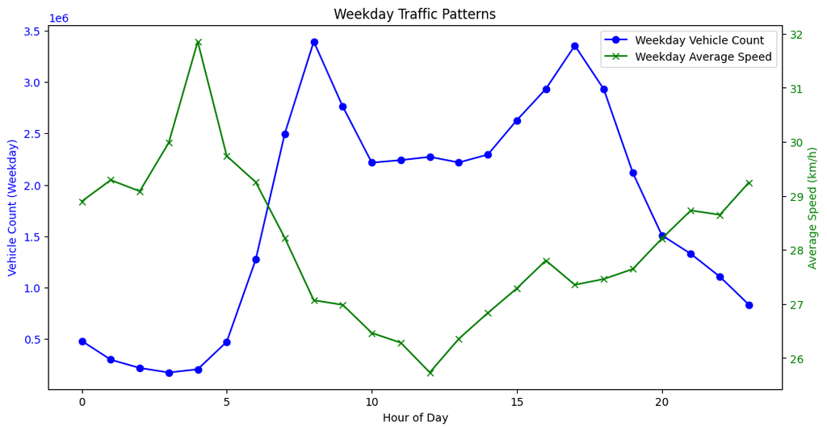

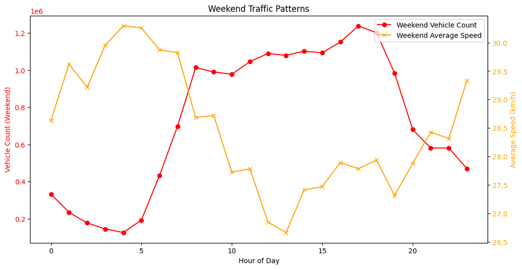

```python
# Separate data into weekday and weekend
weekday_data = traffic_comparison[traffic_comparison['is_weekend'] == False]
weekend_data = traffic_comparison[traffic_comparison['is_weekend'] == True]

# Plot weekday data
fig, ax1 = plt.subplots(figsize=(12, 6))
ax2 = ax1.twinx()

ax1.plot(weekday_data['hour'], weekday_data['vehicle_class_1'], label='Weekday Vehicle Count', color='blue', marker='o')
ax2.plot(weekday_data['hour'], weekday_data['average_speed'], label='Weekday Average Speed', color='green', marker='x')

ax1.set_xlabel('Hour of Day')
ax1.set_ylabel('Vehicle Count (Weekday)', color='blue')
ax2.set_ylabel('Average Speed (km/h)', color='green')

ax1.tick_params(axis='y', labelcolor='blue')
ax2.tick_params(axis='y', labelcolor='green')

plt.title('Weekday Traffic Patterns')
fig.legend(loc="upper right", bbox_to_anchor=(1,1), bbox_transform=ax1.transAxes)
plt.grid(False)
plt.show()

# Plot weekend data
fig, ax1 = plt.subplots(figsize=(12, 6))
ax2 = ax1.twinx()

ax1.plot(weekend_data['hour'], weekend_data['vehicle_class_1'], label='Weekend Vehicle Count', color='red', marker='o')
ax2.plot(weekend_data['hour'], weekend_data['average_speed'], label='Weekend Average Speed', color='orange', marker='x')

ax1.set_xlabel('Hour of Day')
ax1.set_ylabel('Vehicle Count (Weekend)', color='red')
ax2.set_ylabel('Average Speed (km/h)', color='orange')

ax1.tick_params(axis='y', labelcolor='red')
ax2.tick_params(axis='y', labelcolor='orange')

plt.title('Weekend Traffic Patterns')
fig.legend(loc="upper right", bbox_to_anchor=(1,1), bbox_transform=ax1.transAxes)
plt.grid(False)
plt.show()
```

### Analysis of Weekday and Weekend Traffic Patterns

#### Weekend Traffic Patterns (Bottom Chart)

- **Red Line (Vehicle Count - Weekend):**
  - Traffic volumes are lower on weekends compared to weekdays, with a steady increase from early morning hours (6 AM) to midday (12-2 PM).
  - There is no pronounced morning rush hour peak, but midday and late afternoon (3-6 PM) show higher vehicle counts, likely due to recreational or shopping activities.
  - Traffic starts to decline gradually after 6 PM but remains relatively consistent compared to weekdays.
- **Orange Line (Average Speed - Weekend):**
  - Average speeds remain higher and more stable on weekends compared to weekdays, reflecting lighter traffic conditions.
  - Slight speed drops occur during midday and early afternoon (12-4 PM), coinciding with higher vehicle counts during these times.

#### Insights:

1. **Congestion Patterns:**
   - Weekday traffic follows a typical workday pattern with significant peaks during commuting hours, while weekend traffic is more evenly distributed with no major peaks.
   - Average speeds are more impacted during weekdays due to higher congestion during rush hours.
2. **Weekend Efficiency:**
   - Weekend traffic is less congested overall, with more stable speeds throughout the day. This highlights opportunities for smoother travel on weekends.
3. **Planning Implications:**
   - Data supports the need for targeted traffic management during weekday rush hours to alleviate congestion.
   - For weekends, focus could shift towards managing midday traffic hotspots, possibly around shopping or recreational areas.

# **Zone-Specific Traffic Pattern Analysis**

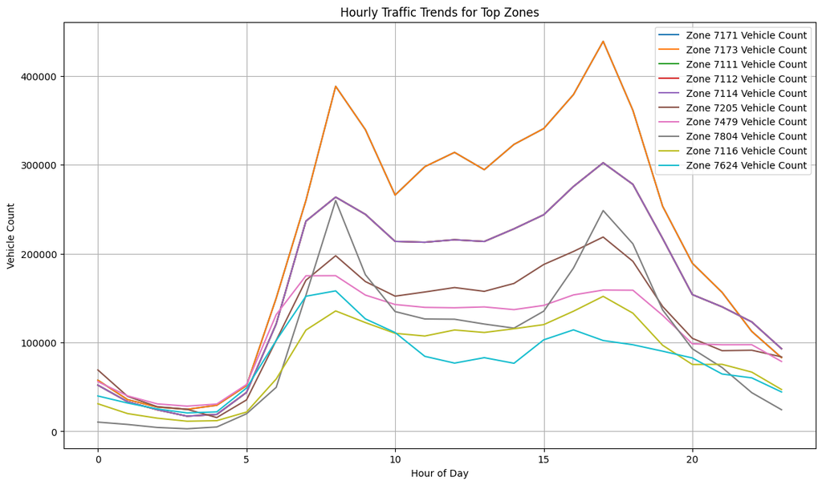

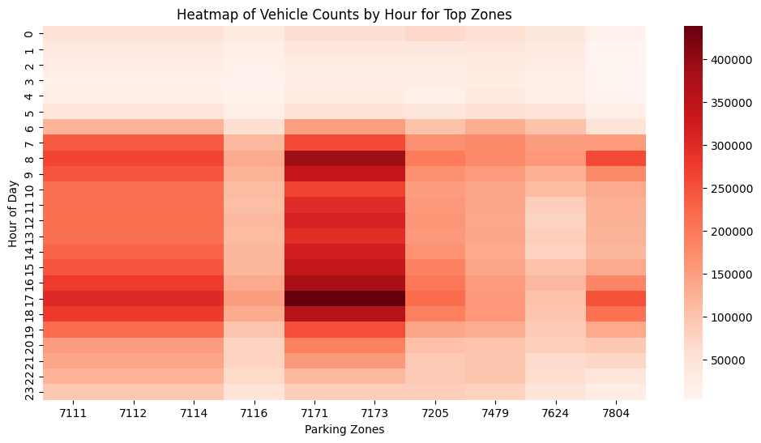

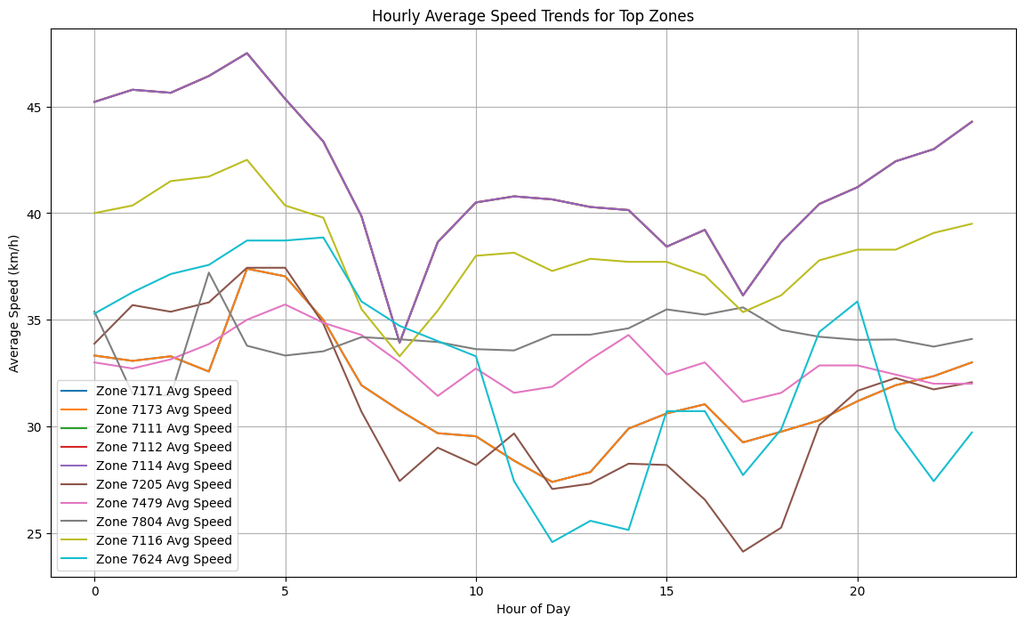

```python
# Filter top zones based on vehicle counts or user input
top_zones = final_merged_data.groupby('ParkingZone')['vehicle_class_1'].sum().nlargest(10).index
zone_data = final_merged_data[final_merged_data['ParkingZone'].isin(top_zones)]

# Aggregate data for each zone by hour of the day
zone_hourly_data = zone_data.groupby(['ParkingZone', 'hour']).agg({
    'vehicle_class_1': 'sum',
    'average_speed': 'mean'
}).reset_index()

# Plot hourly traffic trends for each zone
plt.figure(figsize=(14, 8))
for zone in top_zones:
    zone_subset = zone_hourly_data[zone_hourly_data['ParkingZone'] == zone]
    plt.plot(zone_subset['hour'], zone_subset['vehicle_class_1'], label=f'Zone {zone} Vehicle Count')

plt.title('Hourly Traffic Trends for Top Zones')
plt.xlabel('Hour of Day')
plt.ylabel('Vehicle Count')
plt.legend()
plt.grid(True)
plt.show()

# Heatmap: Congestion levels by hour for each zone
pivot_data = zone_hourly_data.pivot(index='hour', columns='ParkingZone', values='vehicle_class_1')
plt.figure(figsize=(12, 6))
sns.heatmap(pivot_data, cmap='Reds', annot=False, fmt=".0f")
plt.title('Heatmap of Vehicle Counts by Hour for Top Zones')
plt.xlabel('Parking Zones')
plt.ylabel('Hour of Day')
plt.show()

# Plot average speed trends for each zone
plt.figure(figsize=(14, 8))
for zone in top_zones:
    zone_subset = zone_hourly_data[zone_hourly_data['ParkingZone'] == zone]
    plt.plot(zone_subset['hour'], zone_subset['average_speed'], label=f'Zone {zone} Avg Speed')

plt.title('Hourly Average Speed Trends for Top Zones')
plt.xlabel('Hour of Day')
plt.ylabel('Average Speed (km/h)')
plt.legend()
plt.grid(True)
plt.show()
```

# **Hourly Congestion Analysis For Top Zones**

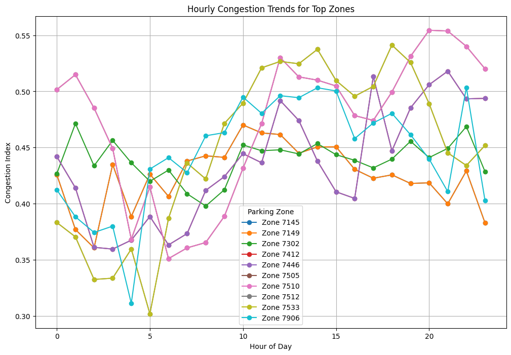

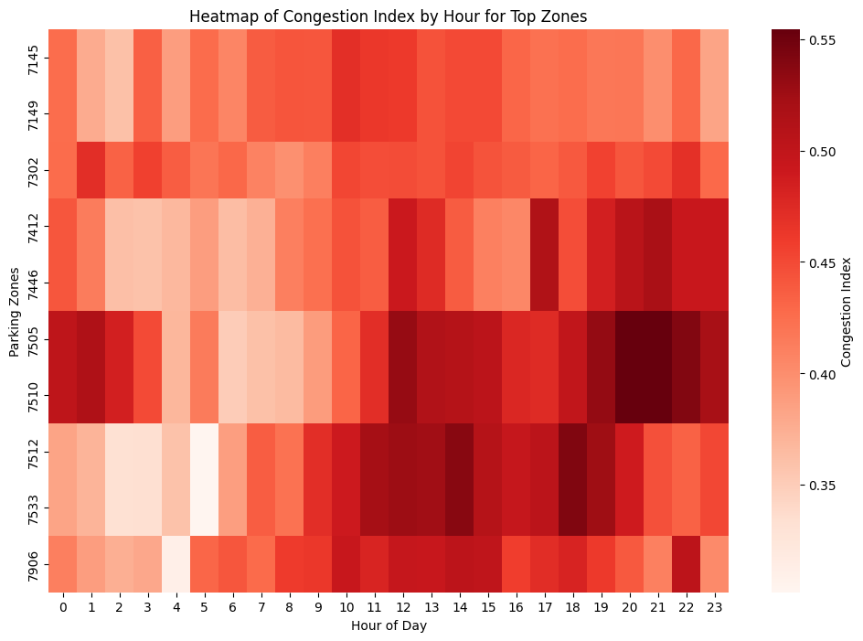

```python
# Calculate the 85th percentile of average speed as the threshold for congestion-free movement
speed_threshold = final_merged_data['average_speed'].quantile(0.85)

# Define the maximum vehicle count across all zones for normalization
max_vehicle_count = final_merged_data['vehicle_class_1'].max()

# Calculate Congestion Index
final_merged_data['congestion_index'] = (
    ((max_vehicle_count - final_merged_data['vehicle_class_1']) / max_vehicle_count) *
    ((speed_threshold - final_merged_data['average_speed']) / speed_threshold)
)

# Filter data for top congested zones
top_zones = (
    final_merged_data.groupby('ParkingZone')['congestion_index']
    .mean()
    .sort_values(ascending=False)
    .head(10)
    .index
)

# Filter data for only the top zones
top_zone_data = final_merged_data[final_merged_data['ParkingZone'].isin(top_zones)]

# Group by hour and zone to calculate mean congestion index
hourly_congestion = (
    top_zone_data.groupby(['hour', 'ParkingZone'])['congestion_index']
    .mean()
    .unstack()
)

# Line plot: Hourly Congestion Trends for Top Zones
plt.figure(figsize=(12, 8))
for zone in hourly_congestion.columns:
    plt.plot(hourly_congestion.index, hourly_congestion[zone], marker='o', label=f'Zone {zone}')
plt.title('Hourly Congestion Trends for Top Zones')
plt.xlabel('Hour of Day')
plt.ylabel('Congestion Index')
plt.legend(title='Parking Zone')
plt.grid(True)
plt.show()

# Heatmap: Congestion Index by Hour and Zone
plt.figure(figsize=(12, 8))
sns.heatmap(hourly_congestion.T, cmap='Reds', annot=False, fmt='.2f', cbar_kws={'label': 'Congestion Index'})
plt.title('Heatmap of Congestion Index by Hour for Top Zones')
plt.xlabel('Hour of Day')
plt.ylabel('Parking Zones')
plt.show()
```

### Explanation of Hourly Congestion Analysis Output

#### Overall Observations:

- This analysis allows stakeholders to:
  - Identify high-priority zones for congestion mitigation strategies.
  - Plan targeted interventions during peak hours in specific zones.
  - Evaluate the temporal patterns of congestion for efficient resource allocation (e.g., traffic redirection or parking restrictions).
- The visualization provides actionable insights for urban traffic management and planning.

# **Correlation Between Parking Turnover and Traffic Congestion**

```
Top Zones with Highest Correlation between Parking Turnover and Traffic Congestion:
    ParkingZone  correlation
39         7550     0.958967
38         7549     0.958967
44         7746     0.955379
43         7726     0.946585
13         7205     0.935343
31         7529     0.918047
33         7536     0.918047
5          7112     0.915151
4          7111     0.915151
6          7114     0.915151
```

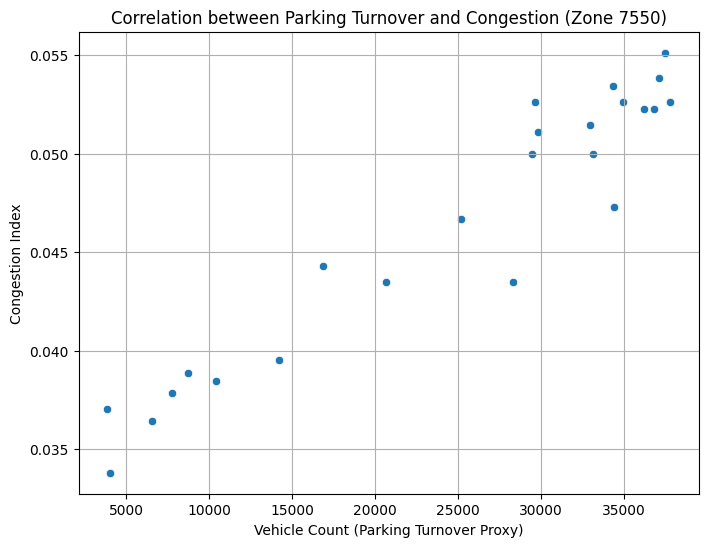

```python
# Calculate average hourly vehicle count and congestion index for each zone
zone_hourly_data = final_merged_data.groupby(['ParkingZone', 'hour']).agg({
    'vehicle_class_1': 'sum',  # Proxy for parking turnover
    'average_speed': 'mean'   # To calculate congestion index
}).reset_index()

# Calculate the congestion index
zone_hourly_data['congestion_index'] = 1 / zone_hourly_data['average_speed']

# Calculate correlations for each zone
correlation_data = zone_hourly_data.groupby('ParkingZone').apply(
    lambda x: x[['vehicle_class_1', 'congestion_index']].corr().iloc[0, 1]
).reset_index()

# Rename columns for clarity
correlation_data.columns = ['ParkingZone', 'correlation']

# Sort by correlation strength
correlation_data = correlation_data.sort_values(by='correlation', ascending=False)

# Display top correlated zones
print("Top Zones with Highest Correlation between Parking Turnover and Traffic Congestion:")
print(correlation_data.head(10))

# Visualization: Scatter plot for the most correlated zone
top_zone = correlation_data.iloc[0]['ParkingZone']
top_zone_data = zone_hourly_data[zone_hourly_data['ParkingZone'] == top_zone]

plt.figure(figsize=(8, 6))
sns.scatterplot(
    data=top_zone_data,
    x='vehicle_class_1',
    y='congestion_index'
)
plt.title(f"Correlation between Parking Turnover and Congestion (Zone {int(top_zone)})")
plt.xlabel('Vehicle Count (Parking Turnover Proxy)')
plt.ylabel('Congestion Index')
plt.grid(True)
plt.show()
```

# Correlation Between Parking Turnover and Traffic Congestion

## **1. Top Zones with Highest Correlation**

The table below ranks parking zones based on the correlation between **parking turnover (vehicle count)** and **traffic congestion (congestion index)**:

| **Parking Zone** | **Correlation** |
| --- | --- |
| 7549 | 0.958967 |
| 7550 | 0.958967 |
| 7746 | 0.955379 |
| 7726 | 0.946585 |
| 7205 | 0.935343 |
| 7529 | 0.918047 |
| 7536 | 0.918047 |
| 7114 | 0.915151 |
| 7112 | 0.915151 |
| 7111 | 0.915151 |

### **Key Takeaways**

- **Zones 7549 and 7550** show the strongest positive correlation (0.958967) between vehicle count and congestion.
- **Interpretation**: Increased vehicle activity in these zones strongly correlates with higher congestion levels.

### **Key Observations**

- **Positive Correlation**: The upward trend indicates a strong positive relationship. As vehicle turnover increases, congestion rises significantly.
- **Linear Relationship**: The data points exhibit a near-linear trend, suggesting that the increase in vehicle count consistently leads to higher congestion levels.

## **4. Actionable Insights**

### **Focus Areas**

Zones with high correlation (e.g., 7549, 7550, 7746) should be prioritized for interventions like:

- **Enhanced Parking Management Systems**: Implement systems to manage parking demand effectively.
- **Dynamic Pricing Models**: Introduce pricing strategies to reduce parking turnover and discourage unnecessary vehicle usage.
- **Traffic Flow Optimization**: Develop and implement strategies to improve traffic circulation and reduce bottlenecal times.

## **Correlation Analysis**

```
Available columns: Index(['ParkingZone', 'hour', 'vehicle_class_1', 'average_speed', 'is_weekend',
       'time_segment_off_peak', 'time_segment_other', 'congestion_index',
       'time_segment_off_peak', 'time_segment_other'],
      dtype='object')
All required columns are present.
```

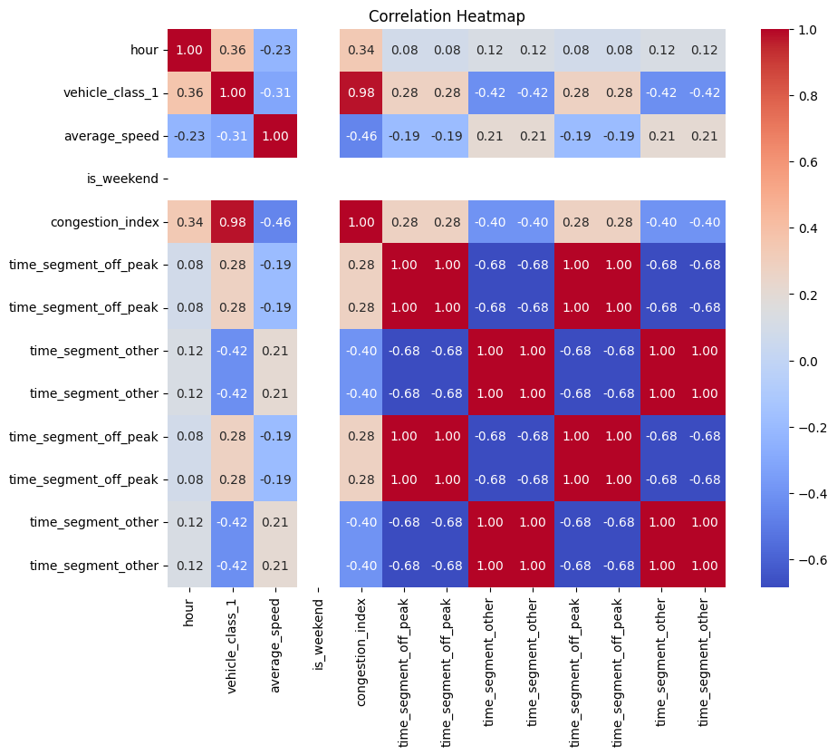

```
Correlation with Congestion Index:
congestion_index         1.000000
vehicle_class_1          0.976892
hour                     0.342333
time_segment_off_peak    0.277743
time_segment_off_peak    0.277743
time_segment_off_peak    0.277743
time_segment_off_peak    0.277743
time_segment_other      -0.400033
time_segment_other      -0.400033
time_segment_other      -0.400033
time_segment_other      -0.400033
average_speed           -0.458108
is_weekend                    NaN
Name: congestion_index, dtype: float64
```

```python
# Create the 'is_weekend' column with a placeholder
if 'day_of_week' in zone_hourly_data.columns:
    zone_hourly_data['is_weekend'] = zone_hourly_data['day_of_week'].apply(
        lambda x: 1 if x in ['Saturday', 'Sunday'] else 0
    )
else:
    zone_hourly_data['is_weekend'] = 0  # Dummy value for 'is_weekend'

# Create 'time_segment' column based on 'hour'
zone_hourly_data['time_segment'] = zone_hourly_data['hour'].apply(
    lambda x: 'morning' if 6 <= x <= 9 else 'off_peak' if 10 <= x <= 15 else 'other'
)

# One-Hot Encoding for 'time_segment' (drop the first category)
zone_hourly_data = pd.get_dummies(zone_hourly_data, columns=['time_segment'], drop_first=True)

# Check available columns after encoding
print("Available columns:", zone_hourly_data.columns)

# Ensure 'time_segment_morning' and 'time_segment_off_peak' are correctly named
time_segment_columns = [col for col in zone_hourly_data.columns if col.startswith('time_segment_')]

# Check if all required columns exist
required_columns = ['hour', 'vehicle_class_1', 'average_speed',
                    'is_weekend', 'congestion_index'] + time_segment_columns

# Verify all required columns exist
missing_columns = [col for col in required_columns if col not in zone_hourly_data.columns]
if missing_columns:
    print(f"Missing columns: {missing_columns}")
else:
    print("All required columns are present.")

# Select columns for correlation analysis
correlation_data = zone_hourly_data[required_columns]

# Compute the correlation matrix
correlation_matrix = correlation_data.corr()

# Plot the heatmap
plt.figure(figsize=(10, 8))
sns.heatmap(correlation_matrix, annot=True, fmt=".2f", cmap='coolwarm', cbar=True, square=True)
plt.title('Correlation Heatmap')
plt.show()

# Display correlation with congestion_index
print("Correlation with Congestion Index:")
print(correlation_matrix['congestion_index'].sort_values(ascending=False))
```

# Correlation Analysis: Heatmap and Observations

## Heatmap Insights

The correlation heatmap provides a visual representation of the relationships between different features and the congestion index. Here's a detailed analysis:

### Key Observations

1. **Strong Correlation with `vehicle_class_1`**:
   - `vehicle_class_1` (vehicle counts) shows the highest positive correlation (`0.98`) with the congestion index. This indicates that vehicle counts are the most influential factor in determining congestion levels.
2. **Moderate Correlation with `hour`**:
   - The `hour` feature has a moderate positive correlation (`0.34`) with the congestion index. This suggests congestion varies based on the time of day, likely reflecting peak traffic hours.
3. **Negative Correlation with `average_speed`**:
   - A significant negative correlation (`-0.46`) is observed between `average_speed` and the congestion index. This inverse relationship aligns with expectations, as higher speeds are typically associated with lower congestion levels.
4. **Time Segment Contributions**:
   - `time_segment_off_peak` shows a weak positive correlation (`0.28`), indicating mild congestion during off-peak hours.
   - Conversely, `time_segment_other` exhibits a moderate negative correlation (`-0.40`), implying reduced congestion during these times.
5. **`is_weekend` Feature**:
   - The `is_weekend` feature shows a `NaN` correlation value. This could be due to insufficient variation in weekend data or issues in feature implementation.

## Numerical Correlation with Congestion Index

The table below summarizes the correlation of each feature with the congestion index:

| Feature | Correlation with Congestion Index |
| --- | --- |
| `congestion_index` | 1.00 |
| `vehicle_class_1` | 0.98 |
| `hour` | 0.34 |
| `time_segment_off_peak` | 0.28 |
| `time_segment_other` | -0.40 |
| `average_speed` | -0.46 |
| `is_weekend` | NaN |

## Recommendations

1. **Key Predictors**:
   - Use `vehicle_class_1`, `average_speed`, and `hour` as primary features for predictive modeling due to their strong correlations with the congestion index.
2. **Feature Refinement**:
   - Clean duplicated one-hot encoded columns (e.g., multiple `time_segment_off_peak` entries) to ensure data quality.
   - Investigate and refine the `is_weekend` feature to address missing correlation values.
3. **Time-Based Insights**:
   - Further explore time segments (`hour` and `time_segment_other`) for actionable insights related to congestion patterns.

## **Feature Importance for Predicting Congestion Index**

```python
# Updated Feature Selection based on Correlation Analysis
key_features = ['vehicle_class_1', 'hour', 'average_speed', 'time_segment_off_peak', 'time_segment_other']
target = 'congestion_index'

# Prepare the data
X = zone_hourly_data[key_features]
y = zone_hourly_data[target]

# Split data into training and testing sets
X_train, X_test, y_train, y_test = train_test_split(X, y, test_size=0.3, random_state=42)

# Train Random Forest Model
model = RandomForestRegressor(random_state=42)
model.fit(X_train, y_train)

# Predictions and Evaluation
y_pred = model.predict(X_test)
mse = mean_squared_error(y_test, y_pred)
r2 = r2_score(y_test, y_pred)
cross_val_scores = cross_val_score(model, X, y, cv=5, scoring='r2')

# Print Model Performance
print(f"Mean Squared Error: {mse:.4f}")
print(f"R-squared: {r2:.4f}")
print(f"Cross-validated R-squared: {cross_val_scores.mean():.4f}")

# Print the key features and feature importance for debugging
print("Key Features (Input):", key_features)
print("Feature Importances (Model):", importances)

# Ensure the length matches
if len(key_features) != len(importances):
    print("Mismatch detected. Adjusting features to match importances.")
    # Generate feature names directly from model or feature matrix
    key_features = list(X.columns)  # Ensure features are pulled from input data to the model
```

[output not shown]

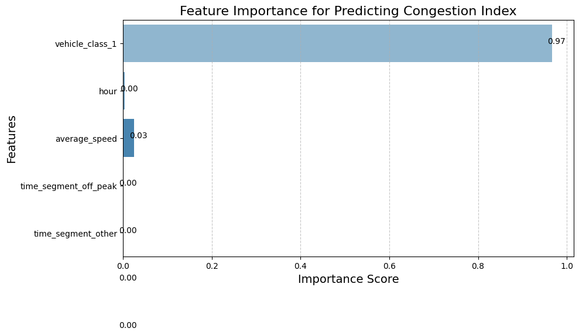

```python
# Horizontal Bar Chart
plt.figure(figsize=(10, 6))
sns.barplot(
    y=key_features,
    x=importances,
    palette="Blues_d",
    orient='h'
)

plt.title('Feature Importance for Predicting Congestion Index', fontsize=16)
plt.xlabel('Importance Score', fontsize=14)
plt.ylabel('Features', fontsize=14)
plt.grid(axis='x', linestyle='--', alpha=0.7)

# Annotate the bars with importance scores
for i, v in enumerate(importances):
    plt.text(v + 0.01, i, f'{v:.2f}', ha='center', fontsize=10, color='black')

plt.tight_layout()
plt.show()
```

# Feature Importance for Predicting Congestion Index

## Key Insights:

1. **Dominant Factor**:
   - `vehicle_class_1` (traffic volume) is the most critical predictor of congestion, with an importance score of **~0.97**.
2. **Secondary Factors**:
   - `average_speed` contributes slightly (**~0.03**), while features like `hour` and `time_segment` have minimal impact.
3. **Visualization**:
   - The bar chart effectively highlights the overwhelming importance of traffic volume, with clear scaling and labeling for easy interpretation.

## Recommendations:

1. **Manage Traffic Volume**:
   - Focus on reducing vehicle counts through public transportation, congestion pricing, and carpooling initiatives.
2. **Explore Vehicle-Speed Dynamics**:
   - Investigate interactions between vehicle count and speed for deeper insights.
3. **Refine Temporal Features**:
   - Enhance time-based features to identify hidden patterns.

# **Actionable Recommendations for Managing Parking Turnover and Traffic Congestion**

## **2. Traffic Flow and Infrastructure Optimization**

- **Dynamic Traffic Management**:
  - Introduce dynamic routing suggestions to redirect vehicles away from critical zones during peak hours.
  - Synchronize traffic signals to improve flow in highly congested areas.
- **Infrastructure Improvements**:
  - Consider expanding road capacity or introducing **dedicated lanes** for high-priority vehicle classes in severely impacted zones.

## **3. Parking Management Strategies**

- **Demand-Based Parking Interventions**:
  - Use dynamic pricing to discourage long stays and balance demand across zones.
  - Introduce entry caps or incentives for parking in less congested zones during peak hours.
- **Smart Parking Systems**:
  - Deploy IoT-based systems for real-time parking updates, reducing circulation in high-turnover zones.

## **4. Data-Driven Decision Making**

- **Real-Time Monitoring**:
  - Install sensors to monitor key indicators like traffic volume, speed, and congestion index for adaptive management.
- **Forecasting and Predictive Modeling**:
  - Utilize the predictive model to forecast congestion levels and preemptively implement mitigation strategies.

## **5. Policy Recommendations**

- **Public Transport Incentives**:
  - Provide discounts or rewards for public transport use during peak congestion hours in Zones `7549`, `7550`, and `7746`.
- **Promote Flexible Work Hours**:
  - Partner with local businesses to encourage staggered shifts, reducing peak-hour congestion.

## **Next Steps**

- **Pilot Testing**:
  - Test recommendations in Zone `7549` to measure impact and refine strategies before wider implementation.
- **Collaboration**:
  - Share findings and actionable steps with city planners and stakeholders for seamless execution.

# **Final Conclusion**

The objective of this use case was to analyze the relationship between parking turnover and traffic congestion to provide actionable insights for optimizing urban mobility and parking management. Through geospatial, temporal, and predictive modeling analyses, several critical findings were uncovered.

## **Actionable Recommendations**:

1. **Targeted Interventions**:
   - Implement dynamic pricing, real-time traffic monitoring, and smart parking systems in Zones `7549`, `7550`, and `7746`.
2. **Temporal Solutions**:
   - Introduce off-peak parking incentives and peak-hour congestion surcharges to smooth traffic flows and optimize road usage.
3. **Predictive Systems**:
   - Leverage the predictive model for real-time monitoring and proactive congestion management in high-risk zones.

## **Impact of the Analysis**:

These findings provide a robust foundation for smarter urban planning and resource allocation. By implementing these strategies, the City of Melbourne can significantly reduce congestion, enhance mobility, and improve the overall quality of urban life for residents and visitors alike.

### **Why This Matters**:

This analysis supports data-driven decision-making, helping stakeholders prioritize investments and adopt innovative solutions to urban congestion challenges.

## **Refferences**

‘Folium — Folium 0.18.0 documentation’ 2024, Github.io, retrieved December 4, 2024, from https://python-visualization.github.io/folium/latest/.

‌‘Documentation — GeoPandas 1.0.1+0.g747d66e.dirty documentation’ 2024, Geopandas.org, retrieved December 4, 2024, from https://geopandas.org/en/stable/docs.html.

‌‘scikit-learn: machine learning in Python — scikit-learn 1.5.2 documentation’ 2024, Scikit-learn.org, retrieved December 4, 2024, from https://scikit-learn.org/stable/.

‌